# 「順序データの分析」補足資料

大学入試センター研究開発部 寺尾 尚大

2021/04/12

この資料は，月刊「臨床栄養」の第138巻5号「回答しやすく・分析しやすい 業務に活かせる！アンケート調査のキホンと応用」の第14回「順序データの分析」で用いたデータ例について，読者の理解をさらに深めるために作成されたものです。

# 対応のない2群の場合

### 分析に使用したデータ

- 分析に使用したのは600名分のデータだが，ここでは6名分のデータを示す
  - groupはインドア群／アウトドア群を表す（インドア群：indoor，アウトドア群：outdoor）
  - freqは間食頻度（1～5）を表す

|  | group | freq |
| --- | --- | --- |
| 1 | indoor | 3 |
| 2 | indoor | 3 |
| 3 | indoor | 3 |
| 301 | outdoor | 3 |
| 302 | outdoor | 4 |
| 303 | outdoor | 5 |

### ヒストグラムの確認

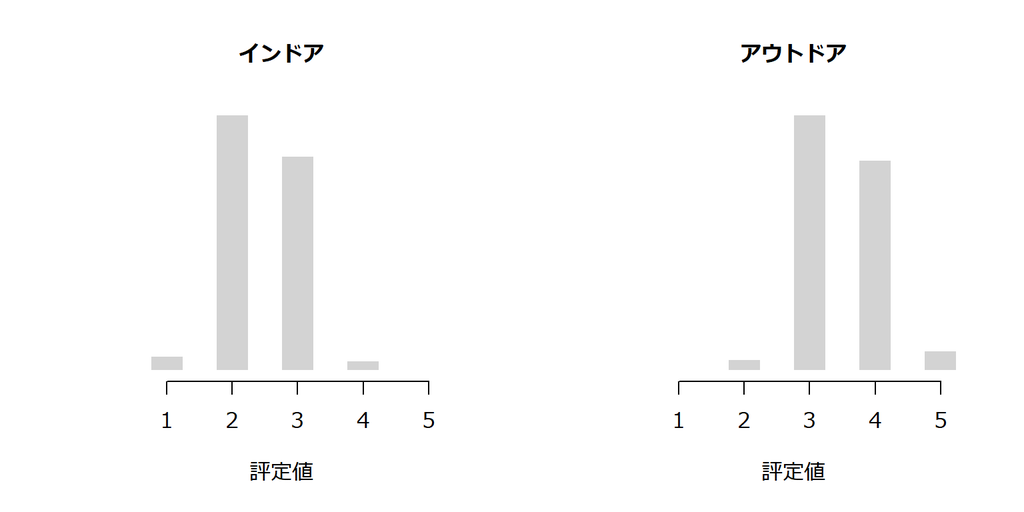

### 度数分布表の確認

- 間食頻度の評定値（1～5）とそれに対応する順序データ・人数を表している
  - 例えば，評定値が1だった9名には，同率に「5」という順序データがつけられている

| 評定値 | 1 | 2 | 3 | 4 | 5 |
| --- | --- | --- | --- | --- | --- |
| 順序データ | 5 | 90.5 | 313.5 | 522 | 594.5 |
| 度数 | 9 | 162 | 284 | 133 | 12 |

### 各群の順位和

#### インドア群 (300名)

```
## [1] 57959.5
```

#### アウトドア群 (300名)

```
## [1] 122340.5
```

### ウィルコクソンの順位和検定（マン・ホイットニーのU検定）

- 本データの分析にあたって使用した統計解析ソフトRでは，`exatRankTests`パッケージの`wilcox.exact()`という関数を用いて検定統計量を算出している
  - 以下の出力結果ではウィルコクソンの順位和検定のWを表示しているように見えるが，実際はマン・ホイットニーのUを計算している
  - 詳細は，[RDocumentation: wilcox.exact](https://www.rdocumentation.org/packages/exactRankTests/versions/0.8-31/topics/wilcox.exact) や [The Wilcoxon Rank Sum Test](https://data.library.virginia.edu/the-wilcoxon-rank-sum-test/) が参考になる

```
##
##  Asymptotic Wilcoxon rank sum test
##
## data:  dat_a[dat_a$group == "indoor", "freq"] and dat_a[dat_a$group == "outdoor", "freq"]
## W = 12810, p-value < 2.2e-16
## alternative hypothesis: true mu is not equal to 0
## 95 percent confidence interval:
##  -1.0000362 -0.9999649
## sample estimates:
## difference in location
##              -1.000052
```

# 対応のある2群の場合

### 分析に使用したデータ

| Heijitsu | Donichi |
| --- | --- |
| 3 | 4 |
| 3 | 4 |
| 3 | 3 |
| 2 | 4 |
| 3 | 4 |
| 1 | 2 |

### ヒストグラムの確認

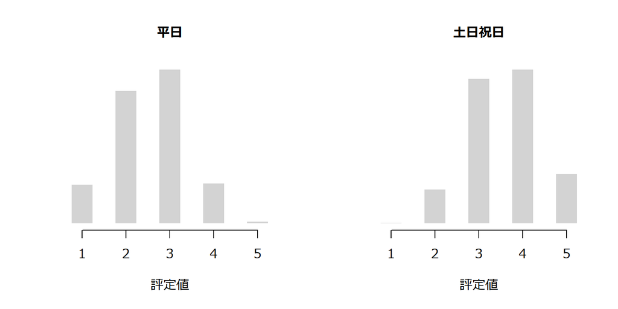

### 度数分布表の確認

- 差得点は，平日の得点ー土日祝日の得点
  - 差得点がプラスなら，平日＞土日祝日
  - 差得点がマイナスなら，平日＜土日祝日
- 差得点の絶対値（0～3）とそれに対応する順序データ・人数を表している
  - 例えば，差得点の絶対値1の人152名には，「76.5」という順序データがつけられている
  - 差得点0の人には順序データをつけない

| 差得点 | 0 | 1 | 2 | 3 |
| --- | --- | --- | --- | --- |
| 順序データ |  | 76.5 | 185.5 | 227.5 |
| 度数 | 64 | 152 | 66 | 18 |

### 差得点がプラスの人とマイナスの人の順位和

#### 差得点がプラスの人 (17名)

```
## [1] 1300.5
```

#### 差得点がマイナスの人 (219名)

```
## [1] 26665.5
```

### ウィルコクソンの符号つき順位検定

```
##
##  Asymptotic Wilcoxon signed rank test
##
## data:  x2$Heijitsu and x2$Donichi
## V = 1300.5, p-value < 2.2e-16
## alternative hypothesis: true mu is not equal to 0
## 95 percent confidence interval:
##  -1.499992 -1.000068
## sample estimates:
## (pseudo)median
##      -1.499947
```

# 対応のない多群の場合

### 分析に使用したデータ例

| grade | score |
| --- | --- |
| 1 | 4 |
| 1 | 3 |
| 1 | 4 |
| 1 | 3 |
| 1 | 3 |
| 1 | 5 |

### ヒストグラムの確認

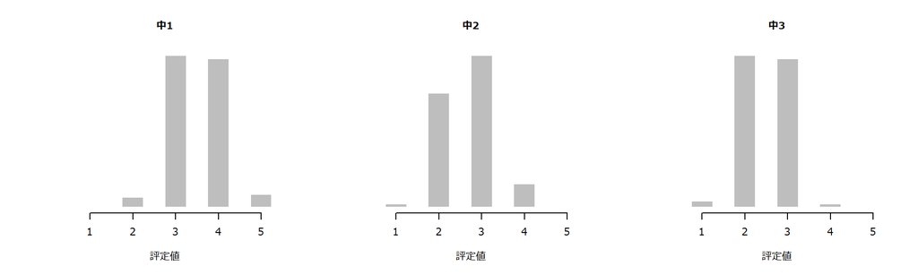

### 度数分布表の確認

| 評定値 | 1 | 2 | 3 | 4 | 5 |
| --- | --- | --- | --- | --- | --- |
| 順序データ | 2 | 49 | 168 | 269 | 298.5 |
| 度数 | 3 | 91 | 147 | 55 | 4 |

### 各群の順位和

#### 中1 (100名)

```
## [1] 21611
```

#### 中2 (100名)

```
## [1] 12801
```

#### 中3 (100名)

```
## [1] 10738
```

### クラスカル・ウォリス検定

- クラスカル・ウォリス検定の検定統計量Hは，自由度（群の数ー1）のカイ二乗分布に近似的に従うことが知られている
  - 以下の出力結果では，`Kruskal-Wallis chi-squared` を検定統計量Hとして解釈する

```
##
##  Kruskal-Wallis rank sum test
##
## data:  dat_c$score by dat_c$grade
## Kruskal-Wallis chi-squared = 104.49, df = 2, p-value < 2.2e-16
```

### 多重比較

```
##
##  Pairwise comparisons using Nemenyi-test with Chi-squared
##                        approximation for independent samples
##
## data:  dat_c$score and dat_c$grade
##
##   1       2
## 2 6.3e-14 -
## 3 < 2e-16 0.19
##
## P value adjustment method: none
```

# 対応のある多群の場合

### 分析に使用したデータ例

| y2018 | y2019 | y2020 |
| --- | --- | --- |
| 2 | 3 | 2 |
| 3 | 3 | 3 |
| 3 | 3 | 2 |
| 4 | 4 | 4 |
| 4 | 3 | 3 |
| 2 | 2 | 2 |

### ヒストグラムの確認

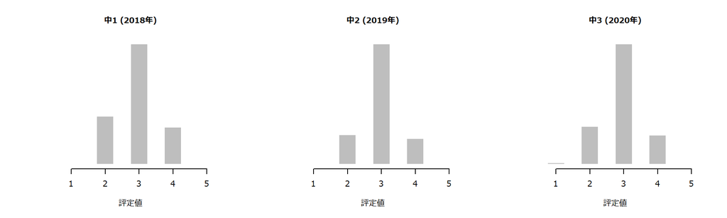

### フリードマンの検定

```
##
##  Friedman rank sum test
##
## data:  m_x31
## Friedman chi-squared = 0.59144, df = 2, p-value = 0.744
```